# Exploring Variations in Sleep Duration Across Occupations

Justin Naidu

2024-04-14

# Introduction

The data set examined in this final project report is the “Sleep, Health, and Lifestyle” data set. This data set was created by Henry Shan and is accessible through the Kaggle website.

#### Data Set Description

The data set contains a wide range of variables related to sleep and daily routines. The data set includes variables such as gender, age, occupation, sleep duration, sleep quality, physical activity, stress level, BMI, blood pressure, heart rate, daily steps taken, and presence of sleep disorders.

#### Primary Objective

The primary objective of my analysis are:

1. Investigate the influence of different professions on the variability in sleep duration by computing the averages in tabular format.
2. Generate scatterplots to visually represent the trends in variability of sleep duration across different occupations.

# Descriptive Analysis

### Tabular Analysis

| **Sleep, Health, and Lifestyle Characteristics** | **N** | **Accountant**, N = 37<sup>1</sup> | **Doctor**, N = 71<sup>1</sup> | **Engineer**, N = 63<sup>1</sup> | **Lawyer**, N = 47<sup>1</sup> | **Manager**, N = 1<sup>1</sup> | **Nurse**, N = 72<sup>1</sup> | **Sales Representative**, N = 2<sup>1</sup> | **Salesperson**, N = 32<sup>1</sup> | **Scientist**, N = 4<sup>1</sup> | **Software Engineer**, N = 4<sup>1</sup> | **Teacher**, N = 40<sup>1</sup> |
| --- | --- | --- | --- | --- | --- | --- | --- | --- | --- | --- | --- | --- |
| Gender | 373 |  |  |  |  |  |  |  |  |  |  |  |
| Female |  | 36 (97%) | 2 (2.8%) | 32 (51%) | 2 (4.3%) | 1 (100%) | 72 (100%) | 0 (0%) | 0 (0%) | 4 (100%) | 0 (0%) | 35 (88%) |
| Male |  | 1 (2.7%) | 69 (97%) | 31 (49%) | 45 (96%) | 0 (0%) | 0 (0%) | 2 (100%) | 32 (100%) | 0 (0%) | 4 (100%) | 5 (13%) |
| Age | 373 | 37 (37, 39) | 31 (30, 32) | 50 (43, 53) | 39 (38, 41) | 45 (45, 45) | 51 (50, 58) | 28 (28, 28) | 44 (43, 44) | 34 (33, 34) | 32 (28, 35) | 44 (36, 45) |
| Duration of Sleep | 373 | 7.20 (7.10, 7.20) | 7.60 (6.05, 7.70) | 8.30 (7.70, 8.40) | 7.30 (7.20, 7.70) | 6.90 (6.90, 6.90) | 6.50 (6.10, 8.10) | 5.90 (5.90, 5.90) | 6.40 (6.30, 6.50) | 6.00 (5.80, 6.20) | 6.80 (6.05, 7.50) | 6.60 (6.60, 6.73) |

<sup>1</sup> n (%); Median (IQR)

### Graphical Analysis

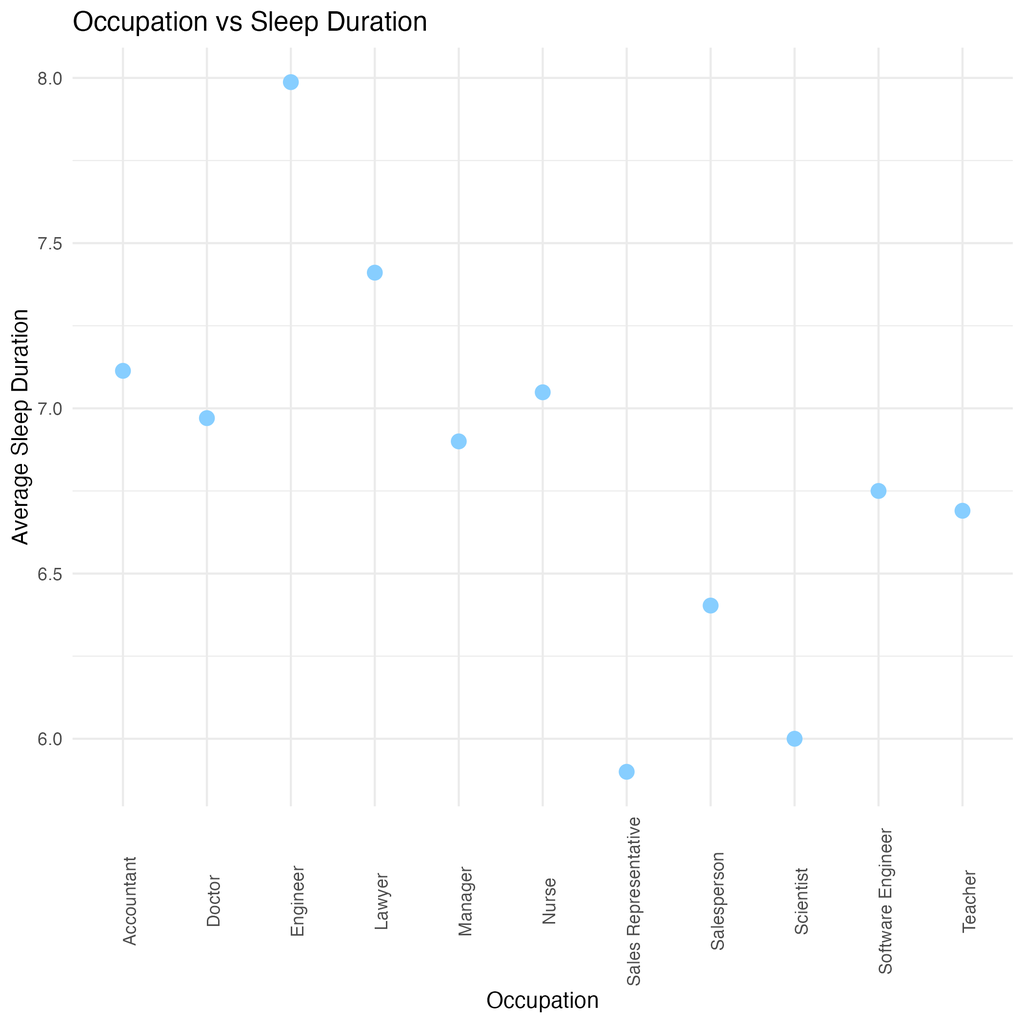